# iris

- Assignment 2
- Part B: Clustering
- Submitted by : Wang Jing 1841341

```python
# Suppress Future Warnings
import warnings
warnings.simplefilter(action='ignore', category=FutureWarning)
warnings.filterwarnings('ignore')
```

# Importing

## Data and libraries

```python
from sklearn.datasets import load_iris
import seaborn as sns
import pandas as pd
import matplotlib. pyplot as plt
```

## Tools

```python
from sklearn import preprocessing
from sklearn.decomposition import PCA
from sklearn.metrics import silhouette_score
from sklearn.metrics.cluster import adjusted_rand_score
```

## Algorithms

```python
from sklearn.cluster import KMeans
from sklearn.mixture import GaussianMixture
from sklearn.cluster import AgglomerativeClustering
```

# Data analysis

```python
# load the iris datasets
iris = pd.read_csv("iris.csv")
iris.sample(5)
```

|  | sepal_length | sepal_width | petal_length | petal_width | species |
| --- | --- | --- | --- | --- | --- |
| 123 | 6.3 | 2.7 | 4.9 | 1.8 | virginica |
| 14 | 5.8 | 4.0 | 1.2 | 0.2 | setosa |
| 53 | 5.5 | 2.3 | 4.0 | 1.3 | versicolor |
| 125 | 7.2 | 3.2 | 6.0 | 1.8 | virginica |
| 149 | 5.9 | 3.0 | 5.1 | 1.8 | virginica |

```python
iris.info()
```

```
<class 'pandas.core.frame.DataFrame'>
RangeIndex: 150 entries, 0 to 149
Data columns (total 5 columns):
sepal_length    150 non-null float64
sepal_width     150 non-null float64
petal_length    150 non-null float64
petal_width     150 non-null float64
species         150 non-null object
dtypes: float64(4), object(1)
memory usage: 5.9+ KB
```

# Data exploration

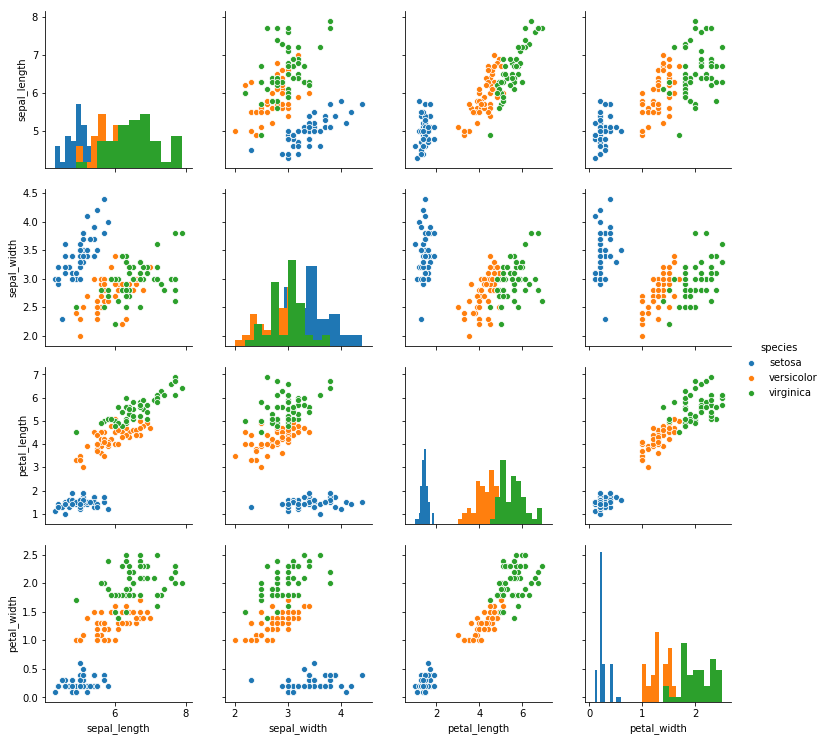

```python
sns.pairplot(iris, hue="species", diag_kind="hist", size=2.6);
```

# Data preperation

## Data split

```python
# split data table into data X and class labels y
X = load_iris().data
H = load_iris().data # standby value, to be use later for evaluation
y = iris.iloc[:,4]
```

## Data scaling

```python
# the data is unbalanced (eg sepallength ~4x petalwidth), so should do feature scaling,
# otherwise the larger features will dominate the others in clustering, etc.
scaler = preprocessing.StandardScaler()
W=scaler.fit(X).transform(X) # standby value, to be use later for evaluation
X=scaler.fit(X).transform(X)
```

## Covariance matrix

```python
mean_vec = np.mean(X, axis=0)
cov_mat = (X - mean_vec).T.dot((X - mean_vec)) / (X.shape[0]-1)
print('Covariance matrix \n%s' %cov_mat)
```

```
Covariance matrix
[[ 1.00671141 -0.11835884  0.87760447  0.82343066]
 [-0.11835884  1.00671141 -0.43131554 -0.36858315]
 [ 0.87760447 -0.43131554  1.00671141  0.96932762]
 [ 0.82343066 -0.36858315  0.96932762  1.00671141]]
```

When the two features are positively correlated, the covariance is greater than zero, otherwise, it has a negative value. Furthermore, if there is no evidence of a correlation between them, hence the covariance is equal to zero.

## Eigendecomposition

```python
cov_mat = np.cov(X.T)
eig_vals, eig_vecs = np.linalg.eig(cov_mat)
print('Eigenvectors \n%s' %eig_vecs)
print('\nEigenvalues \n%s' %eig_vals)
```

```
Eigenvectors
[[ 0.52106591 -0.37741762 -0.71956635  0.26128628]
 [-0.26934744 -0.92329566  0.24438178 -0.12350962]
 [ 0.5804131  -0.02449161  0.14212637 -0.80144925]
 [ 0.56485654 -0.06694199  0.63427274  0.52359713]]

Eigenvalues
[2.93808505 0.9201649  0.14774182 0.02085386]
```

The classic approach to PCA is to perform the eigendecomposition on the covariance matrix Σ, which is a d×d matrix where each element represents the covariance between two features.

Eigenvalues are numerical values that determines how many features you want to retain and eigenvectors are vectors that show which features are closely related in the form of a graph.

## Variance

[figure not shown]

```python
#Fitting the PCA algorithm with our Data
pca = PCA().fit(X)
#Plotting the Cumulative Summation of the Explained Variance
plt.figure()
plt.plot(np.cumsum(pca.explained_variance_ratio_))
plt.xlabel('Number of Components')
plt.ylabel('Variance (%)') #for each component
plt.title('Pulsar Dataset Explained Variance')
plt.show()
```

We choose n_component =2 base on the graph.

## PCA

```python
ndimensions = 2
seed= 0
pca = PCA(n_components=ndimensions, random_state=seed)
pca.fit(X)
X_pca_array = pca.transform(X)
X = pd.DataFrame(X_pca_array, columns=['PC1','PC2']) # PC=principal component
X.info()
```

```
<class 'pandas.core.frame.DataFrame'>
RangeIndex: 150 entries, 0 to 149
Data columns (total 2 columns):
PC1    150 non-null float64
PC2    150 non-null float64
dtypes: float64(2)
memory usage: 2.4 KB
```

```python
#join data back with species
df_plot = X.copy()
df_plot = pd.concat([df_plot, y], axis = 1)
df_plot.sample(10)
```

|  | PC1 | PC2 | species |
| --- | --- | --- | --- |
| 75 | 0.874274 | 0.250793 | versicolor |
| 22 | -2.774345 | 0.458344 | setosa |
| 36 | -2.045146 | 0.661558 | setosa |
| 34 | -2.109975 | -0.460202 | setosa |
| 138 | 0.924825 | 0.017223 | virginica |
| 53 | 0.407483 | -1.754404 | versicolor |
| 119 | 1.263767 | -1.706745 | virginica |
| 140 | 2.014810 | 0.613886 | virginica |
| 86 | 1.048728 | 0.522052 | versicolor |
| 109 | 2.259777 | 1.921010 | virginica |

## Scatter graph

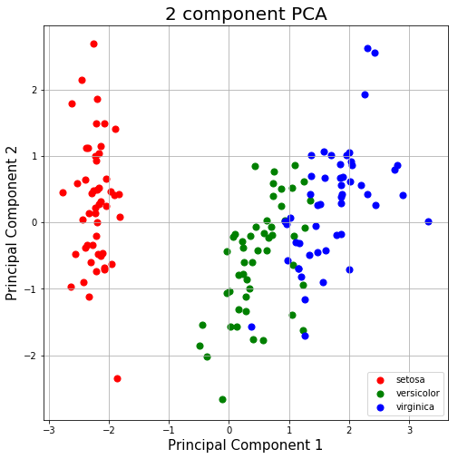

```python
fig = plt.figure(figsize = (8,8))
ax = fig.add_subplot(1,1,1)
ax.set_xlabel('Principal Component 1', fontsize = 15)
ax.set_ylabel('Principal Component 2', fontsize = 15)
ax.set_title('2 component PCA', fontsize = 20)
targets = ['setosa', 'versicolor', 'virginica']
colors = ['r', 'g', 'b']
for target, color in zip(targets,colors):
    indicesToKeep = df_plot['species'] == target
    ax.scatter(df_plot.loc[indicesToKeep, 'PC1']
               ,df_plot.loc[indicesToKeep, 'PC2']
               , c = color
               , s = 50)
ax.legend(targets)
ax.grid()
```

# Hyperparameter tunning

## Elbow method

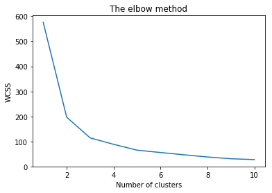

```python
wcss = []
for i in range(1, 11):
    kmeans = KMeans(n_clusters = i, init = 'k-means++', max_iter = 300, n_init = 10, random_state = 0)
    kmeans.fit(X)
    wcss.append(kmeans.inertia_)
#Plotting the results onto a line graph, allowing us to observe 'The elbow'
plt.plot(range(1, 11), wcss)
plt.title('The elbow method')
plt.xlabel('Number of clusters')
plt.ylabel('WCSS') #within cluster sum of squares
plt.show()
```

The elbow method plots sum of squared errors, the lower the better.

## silhouette score

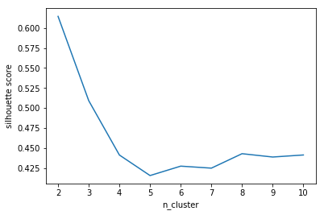

```python
n = []
s = []
for n_cluster in range(2, 11):
    kmeans = KMeans(n_clusters=n_cluster).fit(X)
    label = kmeans.labels_
    sil_coeff = silhouette_score(X, label, metric='euclidean')
    n.append(n_cluster)
    s.append(sil_coeff)
plt.plot(n, s)
plt.ylabel('silhouette score')
plt.xlabel('n_cluster')
```

The silhouette ranges from −1 to +1, where a high value indicates that the object is well matched to its own cluster and poorly matched to neighboring clusters.

# Train model

## KMeans

```
KMeans(algorithm='auto', copy_x=True, init='k-means++', max_iter=300,
    n_clusters=2, n_init=10, n_jobs=None, precompute_distances='auto',
    random_state=None, tol=0.0001, verbose=0)
```

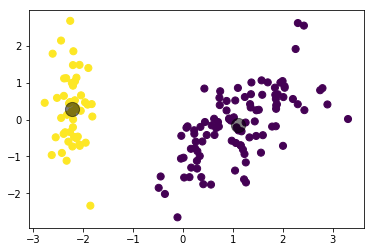

```python
model = KMeans(n_clusters=2)
model.fit(X)
print(model)

y_kmeans = model.predict(X)
kmeans_score_2 = adjusted_rand_score(y, y_kmeans)
# scatter plot the PC1 and PC2
plt.scatter(X['PC1'], X['PC2'], c=y_kmeans, s=50, cmap='viridis')
# show centroid centres as grey circle opacity 50%
centers = model.cluster_centers_
plt.scatter(centers[:, 0], centers[:, 1], c='black', s=200, alpha=0.5)
```

```
KMeans(algorithm='auto', copy_x=True, init='k-means++', max_iter=300,
    n_clusters=3, n_init=10, n_jobs=None, precompute_distances='auto',
    random_state=None, tol=0.0001, verbose=0)
```

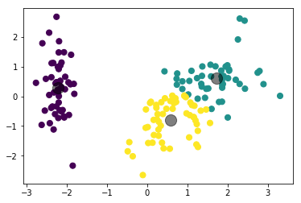

```python
model = KMeans(n_clusters=3)
model.fit(X)
print(model)

y_kmeans = model.predict(X)
kmeans_score_3 = adjusted_rand_score(y, y_kmeans)
# scatter plot the PC1 and PC2
plt.scatter(X['PC1'], X['PC2'], c=y_kmeans, s=50, cmap='viridis')
# show centroid centres as grey circle opacity 50%
centers = model.cluster_centers_
plt.scatter(centers[:, 0], centers[:, 1], c='black', s=200, alpha=0.5)
```

## Gaussian Mixture

```
GaussianMixture(covariance_type='full', init_params='kmeans', max_iter=100,
        means_init=None, n_components=2, n_init=1, precisions_init=None,
        random_state=None, reg_covar=1e-06, tol=0.001, verbose=0,
        verbose_interval=10, warm_start=False, weights_init=None)
```

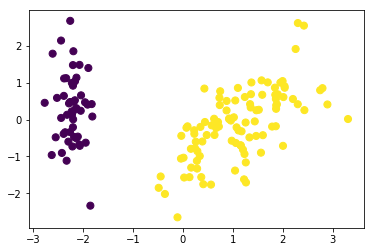

```python
model= GaussianMixture(n_components=2)
model.fit(X)
print(model)


# predict the cluster for each data point
y_gmm = model.predict(X)
gmm_score_2 = adjusted_rand_score(y, y_gmm)
# scatter plot the PC1 and PC2
plt.scatter(X['PC1'], X['PC2'], c=y_gmm, s=50, cmap='viridis')
```

```
GaussianMixture(covariance_type='full', init_params='kmeans', max_iter=100,
        means_init=None, n_components=3, n_init=1, precisions_init=None,
        random_state=None, reg_covar=1e-06, tol=0.001, verbose=0,
        verbose_interval=10, warm_start=False, weights_init=None)
```

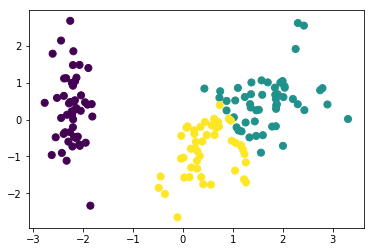

```python
model = GaussianMixture(n_components=3)
model.fit(X)
print(model)

# predict the cluster for each data point
y_gmm = model.predict(X)
gmm_score_3 = adjusted_rand_score(y, y_gmm)
# scatter plot the PC1 and PC2
plt.scatter(X['PC1'], X['PC2'], c=y_gmm, s=50, cmap='viridis')
```

## Agglomerative Clustering

```
AgglomerativeClustering(affinity='euclidean', compute_full_tree='auto',
            connectivity=None, linkage='ward', memory=None, n_clusters=2,
            pooling_func='deprecated')
```

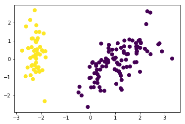

```python
model = AgglomerativeClustering(n_clusters=2, affinity='euclidean', linkage='ward')
# predict the cluster for each data point
y_agg=model.fit_predict(X)
print(model)

agg_score_2 = adjusted_rand_score(y, y_agg)
# scatter plot the PC1 and PC2
plt.scatter(X['PC1'], X['PC2'], c=y_agg, s=50, cmap='viridis')
```

```
AgglomerativeClustering(affinity='euclidean', compute_full_tree='auto',
            connectivity=None, linkage='ward', memory=None, n_clusters=3,
            pooling_func='deprecated')
```

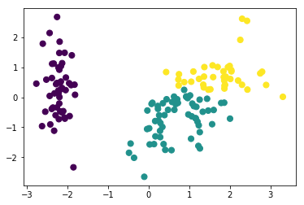

```python
model = AgglomerativeClustering(n_clusters=3, affinity='euclidean', linkage='ward')
# predict the cluster for each data point
y_agg=model.fit_predict(X)
print(model)

agg_score_3 = adjusted_rand_score(y, y_agg)
# scatter plot the PC1 and PC2
plt.scatter(X['PC1'], X['PC2'], c=y_agg, s=50, cmap='viridis')
```

# Evaluation

```python
# Display the scores of various algorithms
results = pd.DataFrame({
    'Model': ['K-means Clustering','Gaussian Mixture','Agglomerative Clustering',],
    'AR score (n=2)': [kmeans_score_2,gmm_score_2,agg_score_2],
    'AR score (n=3)':[kmeans_score_3,gmm_score_3,agg_score_3]
})

# Sort the results according to adjusted rand score (n=3)
result_df = results.sort_values(by='AR score (n=3)', ascending=False)
result_df = result_df.set_index('Model')
result_df
```

| Model | AR score (n=2) | AR score (n=3) |
| --- | --- | --- |
| Gaussian Mixture | 0.568116 | 0.675736 |
| K-means Clustering | 0.568116 | 0.620135 |
| Agglomerative Clustering | 0.568116 | 0.586073 |

- The Adjusted Rand Index is used to measure the similarity of datapoints presents in the clusters.
- higher value indicates that the datapoints are more randomly assigned in the clusters, which is better.
- Gaussian Mixture is the best among the three at finding the actual species labels, as measured by the adjusted Rand score.
- But the score is much lower than what I see from my research, I decided to gmm(n=3) again to test the effect of PCA and scaling on the RA score.

```python
# H is the orginal data without scaling, without PCA
model = GaussianMixture(n_components=3)
model.fit(H)
print(model)

# predict the cluster for each data point
y_gmm = model.predict(H)
gmm_score_3 = adjusted_rand_score(y, y_gmm)
gmm_score_3
```

```
GaussianMixture(covariance_type='full', init_params='kmeans', max_iter=100,
        means_init=None, n_components=3, n_init=1, precisions_init=None,
        random_state=None, reg_covar=1e-06, tol=0.001, verbose=0,
        verbose_interval=10, warm_start=False, weights_init=None)
```

```
0.9038742317748124
```

```python
# W is the scaled data without PCA
model = GaussianMixture(n_components=3)
model.fit(W)
print(model)

# predict the cluster for each data point
y_gmm = model.predict(W)
gmm_score_3 = adjusted_rand_score(y, y_gmm)
gmm_score_3
```

```
GaussianMixture(covariance_type='full', init_params='kmeans', max_iter=100,
        means_init=None, n_components=3, n_init=1, precisions_init=None,
        random_state=None, reg_covar=1e-06, tol=0.001, verbose=0,
        verbose_interval=10, warm_start=False, weights_init=None)
```

```
0.9038742317748124
```

- The adjusted rand score for the non-PCA data is much higher.
- The adjusted rand score for the non-scaled data is the same.
- This shows that scaling is unnecessary and PCA counter-productive when dealing with iris dataset. This is probably due to its small number of initial dimensions.

# Sources

- https://www.kaggle.com/tonzowonzo/simple-k-means-clustering-on-the-iris-dataset
- https://dagster.readthedocs.io/en/0.6.6/sections/learn/guides/data_science/iris-kmeans_2.html
- https://github.com/bhattbhavesh91/k_means_iris_dataset/blob/master/K_in_K_means_Clustering.ipynb
- https://medium.com/analytics-vidhya/implementing-the-k-means-clustering-algorithm-in-python-using-datasets-iris-wine-and-breast-3c98668de474
- https://www.kaggle.com/bburns/iris-exploration-pca-k-means-and-gmm-clustering
- http://rstudio-pubs-static.s3.amazonaws.com/473960_2ac9d64947fa45f88cb70b41fdbb69b6.html
- https://plot.ly/python/v3/ipython-notebooks/principal-component-analysis/